# doc

### 2.2 feature selection by decision tree

#### 2.2.1 split data to train and test

```python
# split train and test data by 50%
import numpy as np
from sklearn.model_selection import train_test_split

X = df3.drop('loan_default',axis=1)
y = df3.loan_default

X_train, X_test, y_train, y_test = train_test_split(X, y, test_size=0.5, random_state=66)
```

#### 2.2.2 deal with missing values

before feature selection by decision tree, we need to deal with missing values

- to run decision tree model first, we impute na first
- reference: https://scikit-learn.org/stable/modules/impute.html#impute

```python
# we replace missing values by mean values for the purpose of feature selection
X_train=X_train.fillna(X_train.mean())
```

#### 2.2.3 simple decision tree for variable selection

Decision tree algorithms such as classification and regression trees (CART) offer importance scores based on the reduction in the criterion used to select split points, like Gini or entropy.

We can use the CART algorithm for feature importance implemented in scikit-learn as the DecisionTreeRegressor and DecisionTreeClassifier classes.

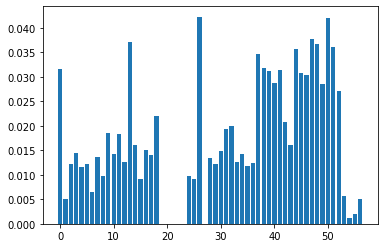

```python
# decision tree for feature importance on a classification problem
from sklearn.datasets import make_classification
from sklearn.tree import DecisionTreeClassifier
from matplotlib import pyplot

# convert AP006 into numeric
X_train=pd.get_dummies(X_train, columns=['AP006'])
# define dataset
X = X_train
y = y_train
# define the model
model = DecisionTreeClassifier()
# fit the model
model.fit(X, y)
# get importance
importance = model.feature_importances_

# plot feature importance
pyplot.bar([x for x in range(len(importance))], importance)
pyplot.show()
```

#### 2.2.4 finalize the features for next step

- Now, we can rank and select features that are most useful to a predictive model.
- According to the graph, we can set 0.01 as a benchmark

```python
# merge variable and importance, for evaluation
importance_data = {'var': X.columns, 'importance': model.feature_importances_}
importance_data=pd.DataFrame(importance_data)
importance_data.sort_values(by=['importance']).head(20)
```

|  | var | importance |
| --- | --- | --- |
| 23 | TD029 | 0.000000 |
| 21 | TD027 | 0.000000 |
| 20 | TD026 | 0.000000 |
| 19 | TD025 | 0.000000 |
| 27 | CR012 | 0.000000 |
| 22 | TD028 | 0.000000 |
| 54 | AP006_api | 0.001086 |
| 55 | AP006_h5 | 0.002046 |
| 56 | AP006_ios | 0.005146 |
| 1 | AP002 | 0.005164 |
| 53 | AP006_android | 0.005736 |
| 6 | AP009 | 0.006539 |
| 15 | TD015 | 0.009174 |
| 25 | CR005 | 0.009190 |
| 24 | CR004 | 0.009689 |
| 8 | TD002 | 0.009719 |
| 4 | AP007 | 0.011575 |
| 35 | PA030 | 0.011875 |
| 2 | AP003 | 0.012131 |
| 5 | AP008 | 0.012183 |

```python
# select variables that have importance value higher than 0.01
selected_var = importance_data.loc[importance_data['importance'] >= 0.01,'var']

# we get new X and y from df3
X = df3.drop('loan_default',axis=1)
y = df3.loan_default

# we split df3 into train and test again
X_train, X_test, y_train, y_test = train_test_split(X, y, test_size=0.5, random_state=66)

# then, only keep selected variables in X_train and X_test
X_train = X_train[selected_var]
X_test = X_test[selected_var]
```

#### 2.2.5 examine na information for remaining variables

The feature selection is complete. We got **X_train** and **X_test** for next steps.

We also want to check summary of missing value for the remaining variables, the graph below shows the number of NA in each column and description for these columns.

```python
# check missing values and the description for remaining variables
# make sure column display full information
pd.set_option('display.max_colwidth', -1)

na_summary2 = X_train.isnull().sum()
na_summary2 = pd.DataFrame(na_summary2)
na_summary2['var'] = na_summary2.index
na_summary2.columns = ['num_missing_values','var']
# here is a dictionary where we can reference description for variables and the number of missing values
Dictionary=pd.merge(na_summary2, Variables_Dictionary, how='left', on='var')
Dictionary
```

[output not shown]

## 3. EDA on X_train

Now, we conduct EDA on train data and explore the business insight behind variables.

We use binning to bing numeric variables, and treat na as categorical variables.

We can get the following business insights

For variables without descriptions

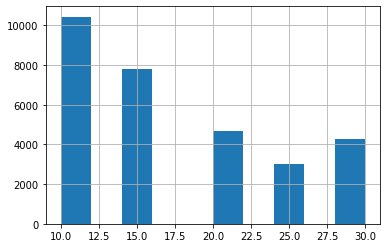

```python
# TD022 has 24.5% missing values, we don't have description for this variable
X_train['TD022'].hist()
```

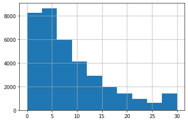

```python
# TD023 has 9% missing values, we don't have description for this variable
X_train['TD023'].hist()
```

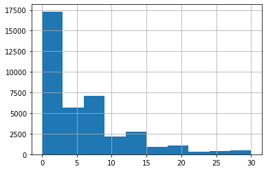

```python
# TD024 has 4.6% missing values, we don't have description for this variable
X_train['TD024'].hist()
```

For variables with descriptions:

### 3.1 deal with NA, and '-99', '-98', '-1' values

for na values:

- 'PA022', 'PA028', 'PA029', 'PA031', 'CD008', 'CD018', 'CD071', 'CD072', 'CD088', 'CD100', 'CD113', 'CD115', 'CD130', 'CD131', 'CD152', 'CD153', 'CD160', 'CD166', 'CD169' has 185 NA values, MB005 has 1391 NA values

for abnormal values:

- PA022 has 788 values for -99, PA028,PA029,PA031 has 25359 '-98' and 788 '-99'
- PA022 also has 25359 values for '-1'
- CD008,CD018,CD071,CD072,CD088,CD100,CD113...CD160 has 1692 '-99'

these values are likely NAs from different, so we default the "-99", "-98", "-1" to NaN

```python
# default '-1','-98',"-99" to NaN in X_train
X_train=X_train.replace(-99.000000,np.NaN)
X_train=X_train.replace(-99.0,np.NaN)
X_train=X_train.replace(-1.0,np.NaN)
X_train=X_train.replace(-98.000000,np.NaN)

# do the same to X_test
X_test=X_test.replace(-99.000000,np.NaN)
X_test=X_test.replace(-99.0,np.NaN)
X_test=X_test.replace(-1.0,np.NaN)
X_test=X_test.replace(-98.000000,np.NaN)
```

```python
# after replacing '-1','-98',"-99" to NaN, we got
X_train['PA028'].value_counts(dropna=False)
```

```
NaN           26332
21.000000     123
22.000000     116
0.000000      111
20.000000     110
             ...
198.833333    1
174.785714    1
91.450000     1
95.769231     1
87.555556     1
Name: PA028, Length: 3283, dtype: int64
```

### 3.2 Binning numeric variables

```python
# first we combine x_train and y_train
train_data = X_train
train_data['loan_default']=y_train
```

```python
# write a function, loop through, to create binning variables for selected features
def binning(var,df):
    df[var + '_bin'] = pd.qcut(df[var],10,duplicates='drop').values.add_categories("NoData").astype(str)
    df[var + '_bin'] = df[var + '_bin'].fillna("NoData")
    df[var + '_bin'].value_counts(dropna=False)

# PA028: AVG_LEN_COLLECTION_OR_HIGH_RISK_CALLS
features = ['PA022','PA028', 'PA029', 'PA031', 'CD008', 'CD018', 'CD071', 'CD072', 'CD088', 'CD100', 'CD113', 'CD115', 'CD130', 'CD131', 'CD152', 'CD153', 'CD160', 'CD166', 'CD169']

for i in features:
    binning(i,train_data)
```

```python
# examine success of binning
train_data['PA028_bin'].value_counts(dropna=False)
```

```
nan                  26332
(45.367, 56.0]       1411
(85.333, 111.0]      1387
(17.75, 26.5]        1379
(-0.001, 17.75]      1368
(68.242, 85.333]     1367
(163.333, 3257.0]    1366
(26.5, 36.0]         1364
(36.0, 45.367]       1356
(111.0, 163.333]     1347
(56.0, 68.242]       1323
Name: PA028_bin, dtype: int64
```

### 3.3 plot the % of Y by X

1) for variables have NA value:

from the graph below, we can see for the independent variables such as 'average length of collection and high risk calls','averge days between application and first collection', most data are missing, and the distribution of loan default is distributed evenly for all bins, we cannot get much business insights from it.

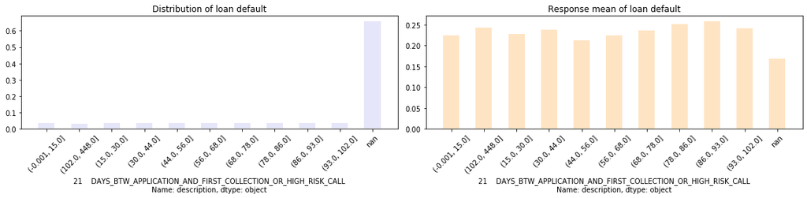

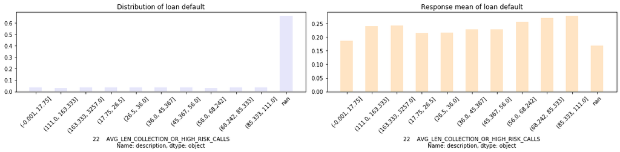

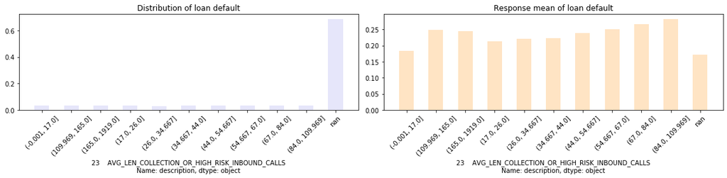

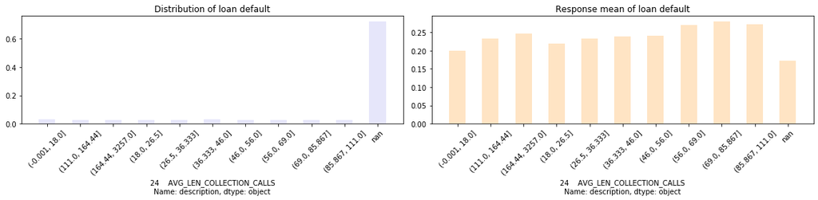

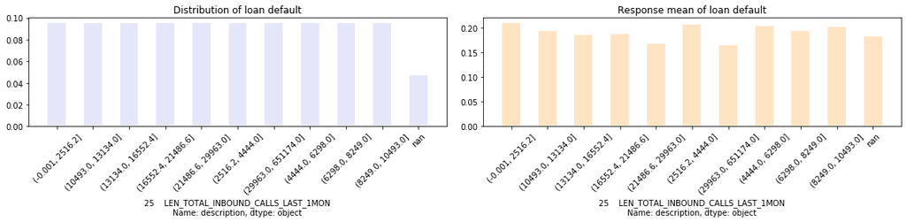

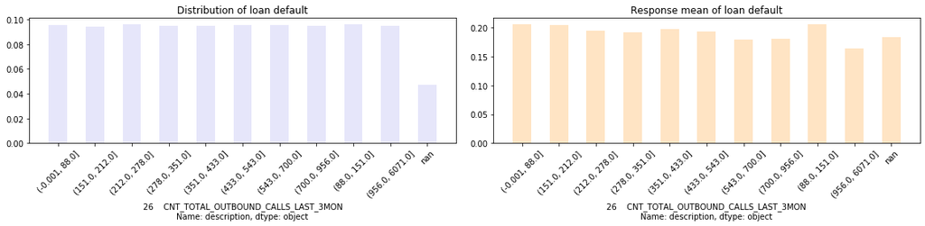

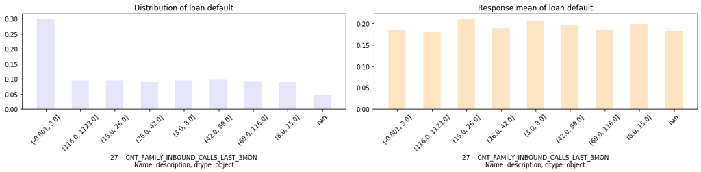

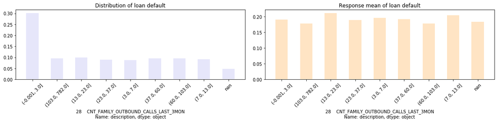

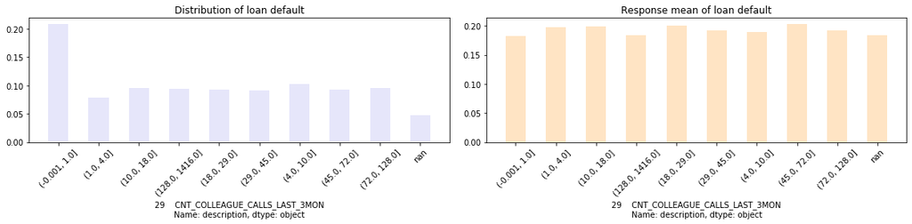

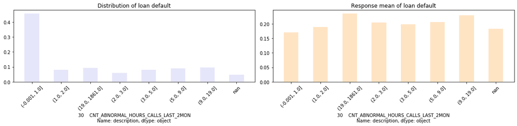

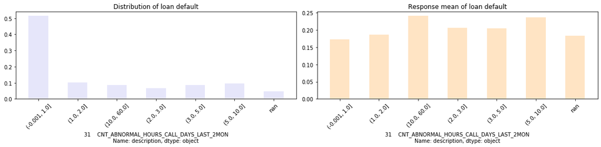

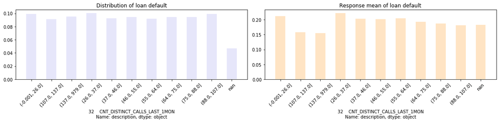

[7 more figures not shown]

```python
# loop through
# Plot the graphs of count distrubution and mean distribution for selected features, we add description of that variable as title
def plot_X_and_Y(var):
    import matplotlib
    import matplotlib.pyplot as plt

    z = train_data.groupby(var +'_bin')['loan_default'].agg(['count','mean']).reset_index()
    z['count_pcnt'] = z['count']/z['count'].sum()
    x = z[var +'_bin']
    y_mean = z['mean']
    count_pcnt = z['count_pcnt']
    ind = np.arange(0, len(x))
    width = .5

    fig = plt.figure(figsize=(16,4))
    plt.subplot(121)
    plt.bar(ind, count_pcnt, width, color='lavender')
    plt.xticks(ind,x.tolist(), rotation=45)
    #plt.ylabel('X')
    plt.title('Distribution of loan default')
    plt.xlabel(str(Dictionary[Dictionary['var']==var]['description']))

    plt.subplot(122)
    plt.bar(ind, y_mean, width, color='bisque')
    #plt.ylabel('Y by X')
    plt.xlabel(str(Dictionary[Dictionary['var']==var]['description']))
    plt.xticks(ind,x.tolist(), rotation=45)
    plt.tight_layout()

    plt.title('Response mean of loan default')
    plt.show()

features = ['PA022','PA028', 'PA029', 'PA031', 'CD008', 'CD018', 'CD071', 'CD072', 'CD088', 'CD100', 'CD113', 'CD115', 'CD130', 'CD131', 'CD152', 'CD153', 'CD160', 'CD166', 'CD169']

for i in features:
    plot_X_and_Y(i)
```

2) For variables do not have NA value

From the graph below, we can observe most people are from age 23 - 36, people who age 20 and 21 are more likely to default

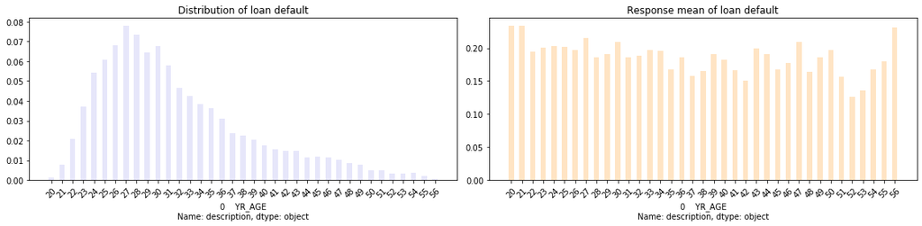

```python
# For variables do not have NA value
features = ['AP001']

for i in features:
    binning(i,train_data)

for i in features:
    plot_X_and_Y(i)
```

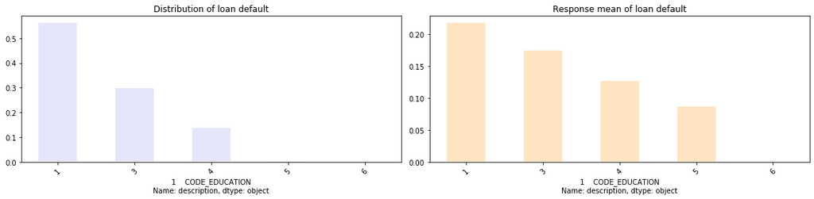

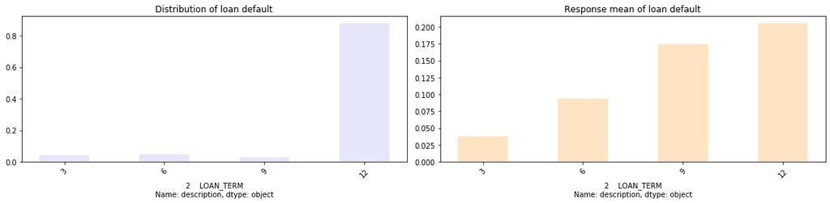

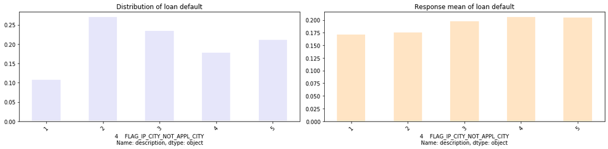

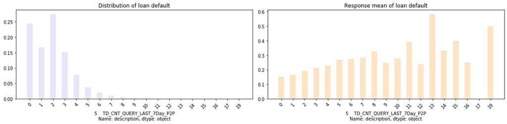

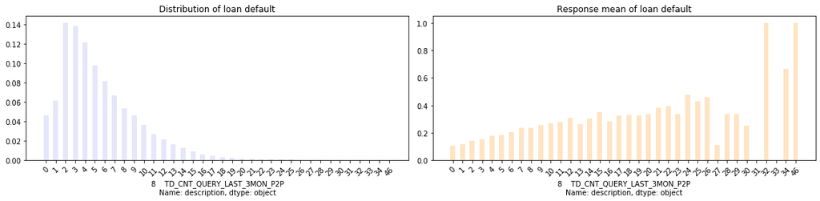

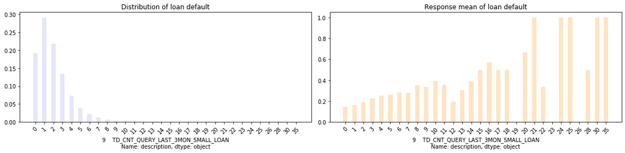

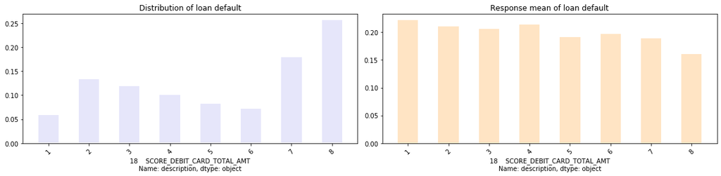

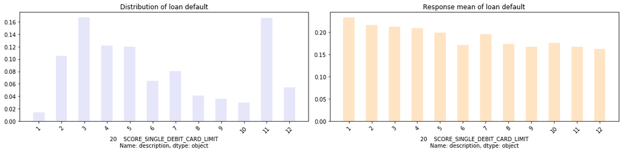

```python
# loop through
# Plot the graphs of count distrubution and mean distribution for selected features, we add description of that variable as title
def plot_X_and_Y_nobin(var):
    import matplotlib
    import matplotlib.pyplot as plt

    z = train_data.groupby(var)['loan_default'].agg(['count','mean']).reset_index()
    z['count_pcnt'] = z['count']/z['count'].sum()
    x = z[var]
    y_mean = z['mean']
    count_pcnt = z['count_pcnt']
    ind = np.arange(0, len(x))
    width = .5

    fig = plt.figure(figsize=(16,4))
    plt.subplot(121)
    plt.bar(ind, count_pcnt, width, color='lavender')
    plt.xticks(ind,x.tolist(), rotation=45)
    #plt.ylabel('X')
    plt.title('Distribution of loan default')
    plt.xlabel(str(Dictionary[Dictionary['var']==var]['description']))

    plt.subplot(122)
    plt.bar(ind, y_mean, width, color='bisque')
    #plt.ylabel('Y by X')
    plt.xlabel(str(Dictionary[Dictionary['var']==var]['description']))
    plt.xticks(ind,x.tolist(), rotation=45)
    plt.tight_layout()

    plt.title('Response mean of loan default')
    plt.show()

features = ['AP003', 'AP004', 'AP008', 'TD001', 'TD009', 'TD010', 'CR017','CR019']

for i in features:
    plot_X_and_Y_nobin(i)
```

from the graph above, we can observe:

- applicants with less education are more likely to default
- applicants with longer period of loan are more likely to default
- applicants whose IP is not the same as application IP are more likely to default
- applicants who have continued query from P2P are more likely to default
- applicants who have less debit card limit are more likely to default

## 4. model prediction

We use logistic model to make prediction.

assumption of logistic model:

- data is linearly (or curvy linearly) separable in space.
- no outliers in data, cuz Logistic regression will push the decision boundary towards the outlier.
- no high correlations (multicollinearity) among the predictors, which we take care of at the beginning by correlation matrix

dicision tree

- Decision Trees are non-linear classifiers

```python
# 4.1. 23 variables has na value, first, we need to deal with missing data, we did this by replacing na with mean value
X_train1=X_train.fillna(X_train.mean())
X_test1=X_test.fillna(X_test.mean())
```

```python
# 4.2. logistics regression modeling
# fit model
from sklearn.linear_model import LogisticRegression
model = LogisticRegression()
model.fit(X_train1, y_train)
```

[output not shown]

```
LogisticRegression(C=1.0, class_weight=None, dual=False, fit_intercept=True,
                   intercept_scaling=1, l1_ratio=None, max_iter=100,
                   multi_class='warn', n_jobs=None, penalty='l2',
                   random_state=None, solver='warn', tol=0.0001, verbose=0,
                   warm_start=False)
```

```python
# 4.3. model prediction
# The first column is the probability that the entry has the -1 label and the second column is the probability that the entry has the +1 label.
y_pred=model.predict_proba(X_test1)[:,1]

predictions = np.where(y_pred>0.6,1,0)

#Accuracy
from sklearn import metrics
print("Accuracy:", metrics.accuracy_score(y_test, predictions))
```

```
Accuracy: 0.804425
```

## 5. model evaluation

Here we evaluate the model prediction results.

### 5.1 Confusion Matrix

Confusion matrix is a table that is often used to describe the performance of a classification model

We can see from the table below that the false negative is relatively high, which is fail to identify a default

- Sensitivity/True Positive Rate: When it's actually yes, how often does it predict yes
- Specificity/True Negative Rate: When it's actually no, how often does it predict no

```python
# Confusion Matrix
from sklearn.metrics import roc_curve, roc_auc_score, accuracy_score, confusion_matrix
confusion_matrix(y_test,predictions)
```

```
array([[32146,    37],
       [ 7774,    43]], dtype=int64)
```

```python
cm = pd.DataFrame(confusion_matrix(y_test,predictions))
cm.rename(columns={0:'Predicted healthy', 1:'Predicted default'},
         index = {0:'Actual healthy',1:'Actual default'},inplace=True)
cm
```

|  | Predicted healthy | Predicted default |
| --- | --- | --- |
| Actual healthy | 32146 | 37 |
| Actual default | 7774 | 43 |

### 5.2 ROC

ROC curve is used to show the trade-off between sensitivity (true positive) and (1-specificity) false positive for every possible cut-off for a test or a combination of tests. The area under an ROC curve is a measure of the usefulness of prediction.

```python
import matplotlib.pyplot as plt
from sklearn.metrics import roc_curve,roc_auc_score

#y_pred = dtree.predict_proba(X_test[features])[:,1]
roc_auc_value = roc_auc_score(y_test,y_pred)
roc_auc_value
```

```
0.6510605122472045
```

```python
fpr, tpr, _ = roc_curve(y_test, y_pred)
[fpr,tpr]
```

```
[array([0.00000000e+00, 3.10723053e-05, 6.21446105e-05, ...,
        9.99906783e-01, 9.99906783e-01, 1.00000000e+00]),
 array([0.        , 0.        , 0.        , ..., 0.99987207, 1.        ,
        1.        ])]
```

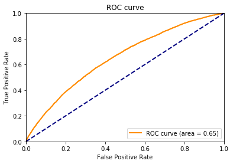

```python
import matplotlib.pyplot as plt
lw=2
plt.figure(figsize=(6,4))
plt.plot(fpr,tpr, color='darkorange',lw=lw,label='ROC curve (area = %0.2f)' %roc_auc_value)
plt.plot([0,1],[0,1], color='navy',lw=lw,linestyle='--')
plt.xlim([0,1])
plt.ylim([0,1])
plt.xlabel('False Positive Rate')
plt.ylabel('True Positive Rate')
plt.title('ROC curve')
plt.legend(loc='lower right')
plt.show()
```

### 5.3 Gains table

why Gains table:

- Gain and Lift charts are used to evaluate performance of classification model. They measure how much better one can expect to do with the predictive model comparing without a model.

```python
df_prep = pd.DataFrame(columns = ['actual','pred'])
df_prep['actual'] = y_test
df_prep['pred'] =y_pred
df_prep = df_prep.sort_values(by='pred',ascending=False)
df_prep['row_id'] = range(0,0+len(df_prep))
df_prep
```

|  | actual | pred | row_id |
| --- | --- | --- | --- |
| 44069 | 0 | 0.895474 | 0 |
| 36721 | 0 | 0.858059 | 1 |
| 14643 | 1 | 0.857244 | 2 |
| 22310 | 0 | 0.832857 | 3 |
| 32848 | 0 | 0.826721 | 4 |
| ... | ... | ... | ... |
| 64679 | 0 | 0.004472 | 39995 |
| 3686 | 0 | 0.004420 | 39996 |
| 36157 | 0 | 0.000331 | 39997 |
| 74174 | 0 | 0.000239 | 39998 |
| 51417 | 0 | 0.000028 | 39999 |

40000 rows × 3 columns

```python
df_prep['decile'] = (df_prep['row_id'] / (len(df_prep)/10)).astype(int)
df_prep.loc[df_prep['decile'] == 10] =9
df_prep['decile'].value_counts()
```

```
9    4000
8    4000
7    4000
6    4000
5    4000
4    4000
3    4000
2    4000
1    4000
0    4000
Name: decile, dtype: int64
```

```python
# Create gains table
gains = df_prep.groupby('decile')['actual'].agg(['count','sum'])
gains.columns = ['count','actual']
gains
```

| decile | count | actual |
| --- | --- | --- |
| 0 | 4000 | 1475 |
| 1 | 4000 | 1184 |
| 2 | 4000 | 983 |
| 3 | 4000 | 871 |
| 4 | 4000 | 763 |
| 5 | 4000 | 631 |
| 6 | 4000 | 619 |
| 7 | 4000 | 572 |
| 8 | 4000 | 414 |
| 9 | 4000 | 305 |

```python
gains['non_actual'] = gains['count'] - gains['actual']
gains['cum_count'] = gains['count'].cumsum()
gains['cum_actual'] = gains['actual'].cumsum()
gains['cum_non_actual'] = gains['non_actual'].cumsum()
gains['percent_cum_actual'] = (gains['cum_actual'] / np.max(gains['cum_actual'])).round(2)
gains['percent_cum_non_actual'] = (gains['cum_non_actual'] / np.max(gains['cum_non_actual'])).round(2)
gains['if_random'] = np.max(gains['cum_actual']) /10
gains['if_random'] = gains['if_random'].cumsum()
gains['lift'] = (gains['cum_actual'] / gains['if_random']).round(2)
gains['K_S'] = np.abs( gains['percent_cum_actual'] - gains['percent_cum_non_actual']  ) * 100
gains['gain'] = (gains['cum_actual'] / gains['cum_count']*100).round(2)
gains
```

| decile | count | actual | non_actual | cum_count | cum_actual | cum_non_actual | percent_cum_actual | percent_cum_non_actual | if_random | lift | K_S | gain |
| --- | --- | --- | --- | --- | --- | --- | --- | --- | --- | --- | --- | --- |
| 0 | 4000 | 1475 | 2525 | 4000 | 1475 | 2525 | 0.19 | 0.08 | 781.7 | 1.89 | 11.0 | 36.88 |
| 1 | 4000 | 1184 | 2816 | 8000 | 2659 | 5341 | 0.34 | 0.17 | 1563.4 | 1.70 | 17.0 | 33.24 |
| 2 | 4000 | 983 | 3017 | 12000 | 3642 | 8358 | 0.47 | 0.26 | 2345.1 | 1.55 | 21.0 | 30.35 |
| 3 | 4000 | 871 | 3129 | 16000 | 4513 | 11487 | 0.58 | 0.36 | 3126.8 | 1.44 | 22.0 | 28.21 |
| 4 | 4000 | 763 | 3237 | 20000 | 5276 | 14724 | 0.67 | 0.46 | 3908.5 | 1.35 | 21.0 | 26.38 |
| 5 | 4000 | 631 | 3369 | 24000 | 5907 | 18093 | 0.76 | 0.56 | 4690.2 | 1.26 | 20.0 | 24.61 |
| 6 | 4000 | 619 | 3381 | 28000 | 6526 | 21474 | 0.83 | 0.67 | 5471.9 | 1.19 | 16.0 | 23.31 |
| 7 | 4000 | 572 | 3428 | 32000 | 7098 | 24902 | 0.91 | 0.77 | 6253.6 | 1.14 | 14.0 | 22.18 |
| 8 | 4000 | 414 | 3586 | 36000 | 7512 | 28488 | 0.96 | 0.89 | 7035.3 | 1.07 | 7.0 | 20.87 |
| 9 | 4000 | 305 | 3695 | 40000 | 7817 | 32183 | 1.00 | 1.00 | 7817.0 | 1.00 | 0.0 | 19.54 |

### 5.4 Cumulative Lift

- Lift is a measure of the effectiveness of a predictive model calculated as the ratio between the results obtained with and without the predictive model.
- from the graph we can see, we are 1.8 times more likely to capture a default as if we use no model.

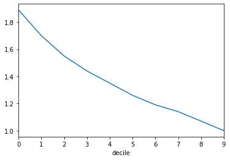

```python
def gains_table(Y_test,y_pred):
    df_prep = pd.DataFrame(columns = ['actual','pred'])
    df_prep['actual'] = Y_test
    df_prep['pred'] =y_pred
    df_prep = df_prep.sort_values(by='pred',ascending=False)
    df_prep['row_id'] = range(0,0+len(df_prep))
    df_prep.head()

    df_prep['decile'] = (df_prep['row_id'] / (len(df_prep)/10)).astype(int)
    df_prep.loc[df_prep['decile'] == 10] =9
    df_prep['decile'].value_counts()

    # Create gains table
    gains = df_prep.groupby('decile')['actual'].agg(['count','sum'])
    gains.columns = ['count','actual']
    gains

    gains['non_actual'] = gains['count'] - gains['actual']
    gains['cum_count'] = gains['count'].cumsum()
    gains['cum_actual'] = gains['actual'].cumsum()
    gains['cum_non_actual'] = gains['non_actual'].cumsum()
    gains['percent_cum_actual'] = (gains['cum_actual'] / np.max(gains['cum_actual'])).round(2)
    gains['percent_cum_non_actual'] = (gains['cum_non_actual'] / np.max(gains['cum_non_actual'])).round(2)
    gains['if_random'] = np.max(gains['cum_actual']) /10
    gains['if_random'] = gains['if_random'].cumsum()
    gains['lift'] = (gains['cum_actual'] / gains['if_random']).round(2)
    gains['K_S'] = np.abs( gains['percent_cum_actual'] - gains['percent_cum_non_actual']  ) * 100
    gains['gain'] = (gains['cum_actual'] / gains['cum_count']*100).round(2)
    return(gains)

gains = gains_table(y_test,y_pred)
gains
gains['lift'].plot.line()
```

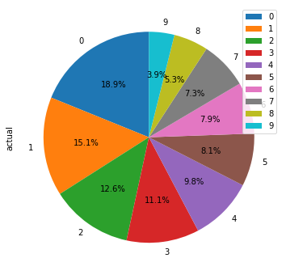

```python
gains.plot.pie(y='actual',figsize=(6,6),autopct = '%1.1f%%', startangle=90)
```

### 5.5 Komogorov-Smirnov (K-S)

K-S evaluate the ability of the model to seperate default and healthy loans in a decile, from the calculation below, we can see the max K-S equals 21.9%.

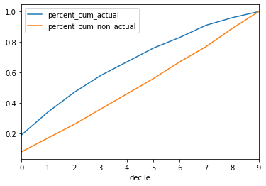

```python
gains[['percent_cum_actual','percent_cum_non_actual']].plot.line()
```

```python
gains['K_S'].max()
```

```
21.999999999999996
```